# Abalone Project

```r
library(here)
library(GGally)
library(readr)
library(CCA)
library(CCP)
library(MASS)
library(psych)
library(knitr)
library(dplyr)
library(e1071)
library(MVN)
library(purrr)
```

**Exploratory Data Analysis**

```r
abal <- read_csv(here("datasets","abalone.csv"))
```

```r
aba <- abal%>% mutate(Sex=factor(Sex))
```

```r
aba
```

| Sex | Length | Diameter | Height | Whole weight | Shucked weight | Viscera weight | Shell weight | Rings |
| --- | --- | --- | --- | --- | --- | --- | --- | --- |
| M | 91 | 73 | 19 | 102.8 | 44.9 | 20.2 | 30.0 | 15 |
| M | 70 | 53 | 18 | 45.1 | 19.9 | 9.7 | 14.0 | 7 |
| F | 106 | 84 | 27 | 135.4 | 51.3 | 28.3 | 42.0 | 9 |
| M | 88 | 73 | 25 | 103.2 | 43.1 | 22.8 | 31.0 | 10 |
| I | 66 | 51 | 16 | 41.0 | 17.9 | 7.9 | 11.0 | 7 |
| I | 85 | 60 | 19 | 70.3 | 28.2 | 15.5 | 24.0 | 8 |
| F | 106 | 83 | 30 | 155.5 | 47.4 | 28.3 | 66.0 | 20 |
| F | 109 | 85 | 25 | 153.6 | 58.8 | 29.9 | 52.0 | 16 |
| M | 95 | 74 | 25 | 101.9 | 43.3 | 22.5 | 33.0 | 9 |
| F | 110 | 88 | 30 | 178.9 | 62.9 | 30.2 | 64.0 | 19 |

[output cut: 990 more lines]

```r
summary(aba)
```

```
 Sex          Length         Diameter          Height       Whole weight   Shucked weight
 F:1307   Min.   : 15.0   Min.   : 11.00   Min.   :  0.0   Min.   :  0.4   Min.   :  0.20
 I:1342   1st Qu.: 90.0   1st Qu.: 70.00   1st Qu.: 23.0   1st Qu.: 88.3   1st Qu.: 37.20
 M:1528   Median :109.0   Median : 85.00   Median : 28.0   Median :159.9   Median : 67.20
          Mean   :104.8   Mean   : 81.58   Mean   : 27.9   Mean   :165.7   Mean   : 71.87
          3rd Qu.:123.0   3rd Qu.: 96.00   3rd Qu.: 33.0   3rd Qu.:230.6   3rd Qu.:100.40
          Max.   :163.0   Max.   :130.00   Max.   :226.0   Max.   :565.1   Max.   :297.60
 Viscera weight    Shell weight        Rings
 Min.   :  0.10   Min.   :  0.30   Min.   : 1.000
 1st Qu.: 18.70   1st Qu.: 26.00   1st Qu.: 8.000
 Median : 34.20   Median : 46.80   Median : 9.000
 Mean   : 36.12   Mean   : 47.77   Mean   : 9.934
 3rd Qu.: 50.60   3rd Qu.: 65.80   3rd Qu.:11.000
 Max.   :152.00   Max.   :201.00   Max.   :29.000
```

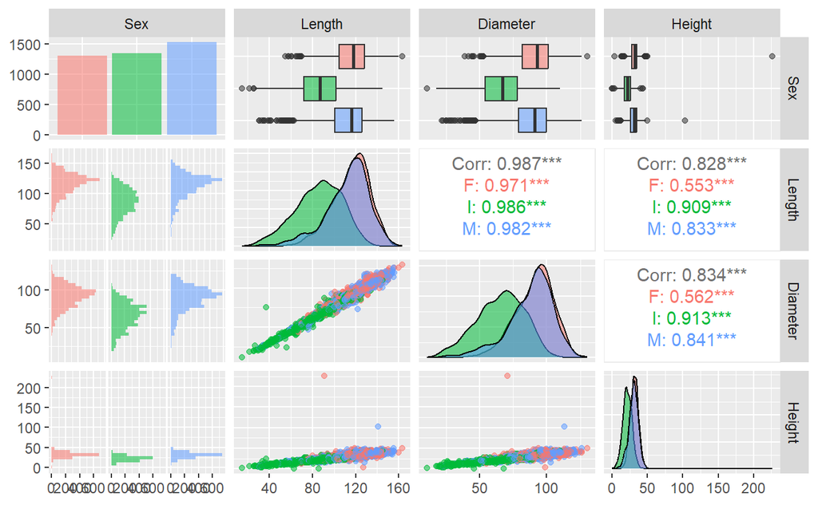

```r
ggpairs(aba[,c(1:4)], aes(colour=Sex, alpha = 0.3))
```

In order to separate infants from the other abalone, We store the infant abalone in dataset **iab**

```r
 iab <- aba %>% filter(Sex =="I")
 iab
```

| Sex | Length | Diameter | Height | Whole weight | Shucked weight | Viscera weight | Shell weight | Rings |
| --- | --- | --- | --- | --- | --- | --- | --- | --- |
| I | 66 | 51 | 16 | 41.0 | 17.9 | 7.9 | 11.0 | 7 |
| I | 85 | 60 | 19 | 70.3 | 28.2 | 15.5 | 24.0 | 8 |
| I | 71 | 56 | 17 | 58.1 | 19.0 | 7.9 | 23.0 | 7 |
| I | 76 | 55 | 20 | 45.1 | 16.0 | 9.8 | 17.0 | 10 |
| I | 48 | 35 | 9 | 14.0 | 6.3 | 4.7 | 4.0 | 5 |
| I | 41 | 30 | 11 | 8.4 | 5.1 | 3.0 | 2.4 | 5 |
| I | 42 | 30 | 10 | 8.4 | 3.5 | 2.5 | 3.0 | 4 |
| I | 78 | 59 | 19 | 40.6 | 17.5 | 9.0 | 15.0 | 7 |
| I | 65 | 49 | 14 | 32.2 | 15.1 | 5.1 | 9.0 | 6 |
| I | 104 | 82 | 24 | 119.0 | 47.7 | 22.2 | 38.0 | 8 |

[output cut: 990 more lines]

The rest of the adult abalone in dataset **fmab**

```r
fmab <-aba %>% filter(Sex !="I")
fmab
```

| Sex | Length | Diameter | Height | Whole weight | Shucked weight | Viscera weight | Shell weight | Rings |
| --- | --- | --- | --- | --- | --- | --- | --- | --- |
| M | 91 | 73 | 19 | 102.8 | 44.9 | 20.2 | 30.0 | 15 |
| M | 70 | 53 | 18 | 45.1 | 19.9 | 9.7 | 14.0 | 7 |
| F | 106 | 84 | 27 | 135.4 | 51.3 | 28.3 | 42.0 | 9 |
| M | 88 | 73 | 25 | 103.2 | 43.1 | 22.8 | 31.0 | 10 |
| F | 106 | 83 | 30 | 155.5 | 47.4 | 28.3 | 66.0 | 20 |
| F | 109 | 85 | 25 | 153.6 | 58.8 | 29.9 | 52.0 | 16 |
| M | 95 | 74 | 25 | 101.9 | 43.3 | 22.5 | 33.0 | 9 |
| F | 110 | 88 | 30 | 178.9 | 62.9 | 30.2 | 64.0 | 19 |
| F | 105 | 76 | 28 | 121.3 | 38.8 | 29.5 | 42.0 | 14 |
| M | 86 | 70 | 22 | 81.2 | 33.5 | 16.2 | 27.0 | 10 |

[output cut: 990 more lines]

We test for the difference in length, diameter, height of an infant ablone and adult abalone with Welch two sample t- tests

```r
t.test(iab$Length,fmab$Length)
```

```
    Welch Two Sample t-test

data:  iab$Length and fmab$Length
t = -40.819, df = 2355.2, p-value < 2.2e-16
alternative hypothesis: true difference in means is not equal to 0
95 percent confidence interval:
 -29.72371 -26.99874
sample estimates:
mean of x mean of y
 85.54918 113.91041
```

```r
t.test(iab$Diameter,fmab$Diameter)
```

```
    Welch Two Sample t-test

data:  iab$Diameter and fmab$Diameter
t = -42.455, df = 2388.1, p-value < 2.2e-16
alternative hypothesis: true difference in means is not equal to 0
95 percent confidence interval:
 -25.09042 -22.87492
sample estimates:
mean of x mean of y
 65.29881  89.28148
```

```r
t.test(iab$Height, fmab$Height)
```

```
    Welch Two Sample t-test

data:  iab$Height and fmab$Height
t = -41.427, df = 3037.4, p-value < 2.2e-16
alternative hypothesis: true difference in means is not equal to 0
95 percent confidence interval:
 -9.727992 -8.848752
sample estimates:
mean of x mean of y
 21.59911  30.88748
```

The p value of less than 2.2 x 10^-16 in the three tests above shows that the length, diameter, height of infant abalone is not similar to adult abalone. These features can therefore be used to distinguish between infants and adults.

A 95% confidence interval is used to correctly identify an infant abalone from it Length Diameter and Height.

```r
t.test(iab$Length)
```

```
    One Sample t-test

data:  iab$Length
t = 143.95, df = 1341, p-value < 2.2e-16
alternative hypothesis: true mean is not equal to 0
95 percent confidence interval:
 84.38330 86.71506
sample estimates:
mean of x
 85.54918
```

```r
t.test(iab$Diameter)
```

```
    One Sample t-test

data:  iab$Diameter
t = 135.75, df = 1341, p-value < 2.2e-16
alternative hypothesis: true mean is not equal to 0
95 percent confidence interval:
 64.35515 66.24246
sample estimates:
mean of x
 65.29881
```

```r
t.test(iab$Height)
```

```
    One Sample t-test

data:  iab$Height
t = 123.65, df = 1341, p-value < 2.2e-16
alternative hypothesis: true mean is not equal to 0
95 percent confidence interval:
 21.25644 21.94178
sample estimates:
mean of x
 21.59911
```

|  | **Mean** | **95% Confidence range** |
| --- | --- | --- |
| **Length** | 85.54 mm | 84.38 mm to 86.71 mm |
| **Diameter** | 65.3 mm | 64.35 mm to 66.24 mm |
| **Height** | 21.6 mm | 21.25 mm to 21.94 mm |

**Table 1. Range of Length , Diameter and Height of Infant abalone at 95% confidence**

From the above table any abalone which has a Length up to 87mm, Diameter up to 67mm and Height up to 22mm can be considered as infants and therefore should be avoided from harvesting.

For abalone beyond these dimensions we use a classification model which classifies an abalone based on its length, diameter and height.

For this purpose we compare a Support Vector Machine model (SVM) , Linear Discriminant Analysis (LDA) and Quadratic Discriminant Analysis (QDA)

**Testing for Multivariate Normality of Length, Diameter and Height**

```r
(mvn(aba[,c(2,3,4)]))$univariateNormality
```

|  | Test | Variable | Statistic | p value | Normality |
| --- | --- | --- | --- | --- | --- |
| 1 | Anderson-Darling | Length | 36.6212 | <0.001 | NO |
| 2 | Anderson-Darling | Diameter | 36.4378 | <0.001 | NO |
| 3 | Anderson-Darling | Height | 14.4931 | <0.001 | NO |

As the three independent variables are not univairate or multivariate normal, by default, SVM could the preferable classifier model

**Support Vector Machine (SVM)**

```r
set.seed(111)
ind <- sample(2, nrow(aba),
              replace = TRUE,
              prob = c(.8, .2))
training <- aba[ind==1,]
testing <- aba[ind==2,]
```

```r
(tuasvm <- tune.svm(Sex ~ Length+ Diameter + Height,data=training,kernel="radial", gamma = 10^(-1:1), cost = 10^(-1:1)))
```

```
Parameter tuning of ‘svm’:

- sampling method: 10-fold cross validation

- best parameters:
```

|  | gamma | cost |
| --- | --- | --- |
|  | 1 | 10 |

```
- best performance: 0.4692079
```

```r
tuasvm$best.parameters
```

|  | gamma | cost |
| --- | --- | --- |
| 8 | 1 | 10 |

```r
tuasvm$best.model
```

```
Call:
best.svm(x = Sex ~ Length + Diameter + Height, data = training, gamma = 10^(-1:1), cost = 10^(-1:1),
    kernel = "radial")


Parameters:
   SVM-Type:  C-classification
 SVM-Kernel:  radial
       cost:  10

Number of Support Vectors:  2899
```

```r
(asvm <- svm(Sex~Length + Diameter+ Height ,data = training, kernel="radial",gamma = tuasvm$best.parameters[1,1], cost = tuasvm$best.parameters[1,2], cross = 10))
```

```
Call:
svm(formula = Sex ~ Length + Diameter + Height, data = training, kernel = "radial", gamma = tuasvm$best.parameters[1,
    1], cost = tuasvm$best.parameters[1, 2], cross = 10)


Parameters:
   SVM-Type:  C-classification
 SVM-Kernel:  radial
       cost:  10

Number of Support Vectors:  2899
```

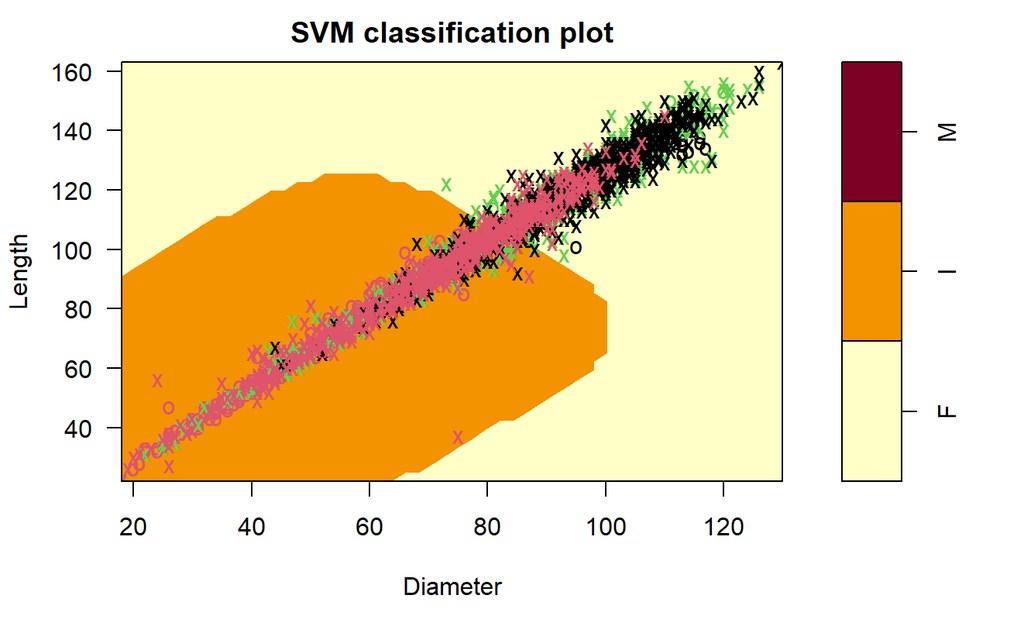

```r
plot(asvm, data = training, Length~Diameter)
```

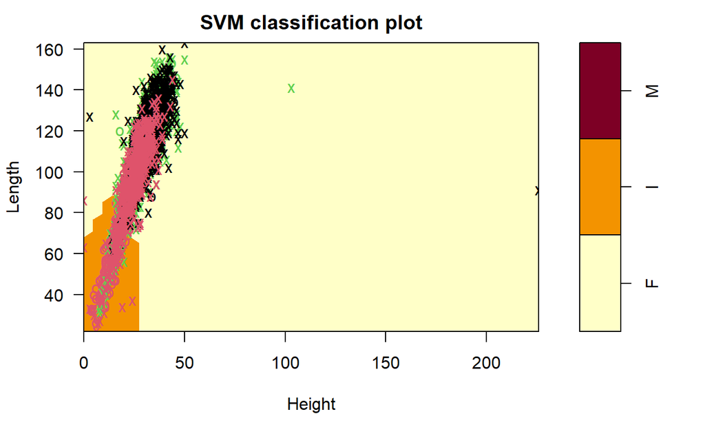

```r
plot(asvm, data = training, Length~Height)
```

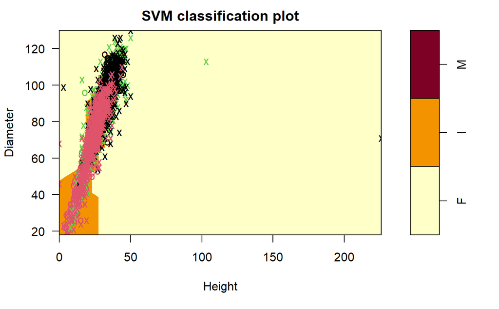

```r
plot(asvm, data = training, Diameter~Height)
```

```r
pasvm <- predict(asvm, newdata = data.frame(Length = testing[,2], Diameter = testing[,3], Height = testing[,4]))
```

```r
(tasvm <-table(truth = testing$Sex, prediction = pasvm))
```

```
     prediction
truth   F   I   M
    F  28  46 177
    I   2 185  60
    M  32  69 185
```

```r
sum(diag(tasvm)/sum(tasvm))*100
```

```
[1] 50.76531
```

```r
tasvm[1.1]/nrow(testing %>% filter(Sex =="F"))*100
```

```
[1] 11.15538
```

```r
tasvm[2,2]/nrow(testing %>% filter(Sex =="I"))*100
```

```
[1] 74.89879
```

```r
tasvm[3,3]/nrow(testing %>% filter(Sex =="M"))*100
```

```
[1] 64.68531
```

The SVM model has an accuracy of 50.7%

**Linear Discriminant Analysis (LDA)**

```r
summary(alda<- lda(Sex~Length + Diameter + Height, data = aba, CV = TRUE))
```

```
          Length Class  Mode
class      4177  factor numeric
posterior 12531  -none- numeric
terms         3  terms  call
call          4  -none- call
xlevels       0  -none- list
```

```r
(talda <- table(Truth = aba$Sex, Prediction = alda$class))
```

```
     Prediction
Truth   F   I   M
    F 292 182 833
    I   9 930 403
    M 292 291 945
```

```r
sum(diag(talda)/sum(talda))*100
```

```
[1] 51.87934
```

```r
talda[1,1]/nrow(aba %>% filter(Sex =="F"))*100
```

```
[1] 22.34124
```

```r
talda[2,2]/nrow(aba %>% filter(Sex =="I"))*100
```

```
[1] 69.29955
```

```r
talda[3,3]/nrow(aba %>% filter(Sex =="M"))*100
```

```
[1] 61.84555
```

The LDA model has an accuracy of 51.88%

**Quadratic Discriminant analysis**

```r
summary(aqda<- qda(Sex~Length + Diameter + Height, data = aba, CV = TRUE))
```

```
          Length Class  Mode
class      4177  factor numeric
posterior 12531  -none- numeric
terms         3  terms  call
call          4  -none- call
xlevels       0  -none- list
```

```r
(taqda <- table(Truth = aba$Sex, Prediction = aqda$class))
```

```
     Prediction
Truth    F    I    M
    F  188  204  914
    I   52  976  314
    M  189  325 1014
```

```r
sum(diag(taqda)/sum(taqda))*100
```

```
[1] 52.15517
```

```r
taqda[1,1]/nrow(aba %>% filter(Sex =="F"))*100
```

```
[1] 14.38409
```

```r
talda[2,2]/nrow(aba %>% filter(Sex =="I"))*100
```

```
[1] 69.29955
```

```r
talda[3,3]/nrow(aba %>% filter(Sex =="M"))*100
```

```
[1] 61.84555
```

The QDA model has an accuracy of 52.15%

[output not shown]

**Table 2. Classifier model accuracy**

**Testing for Multivariate Normality of Viscera Weight and Shucked Weight**

```r
mvn(aba[,c(6,7)])
```

| Test | HZ | p value | MVN |
| --- | --- | --- | --- |
| Henze-Zirkler | 83.34519 | 0 | NO |

|  | Test | Variable | Statistic | p value | Normality |
| --- | --- | --- | --- | --- | --- |
| 1 | Anderson-Darling | Shucked weight | 27.2292 | <0.001 | NO |
| 2 | Anderson-Darling | Viscera weight | 25.7111 | <0.001 | NO |

|  | n | Mean | Std.Dev | Median | Min | Max | 25th | 75th | Skew | Kurtosis |
| --- | --- | --- | --- | --- | --- | --- | --- | --- | --- | --- |
| Shucked weight | 4177 | 71.87350 | 44.39259 | 67.2 | 0.2 | 297.6 | 37.2 | 100.4 | 0.7185815 | 0.59125529 |
| Viscera weight | 4177 | 36.11872 | 21.92285 | 34.2 | 0.1 | 152.0 | 18.7 | 50.6 | 0.5914271 | 0.08099937 |

```
NA
```

**Correlation Analysis**

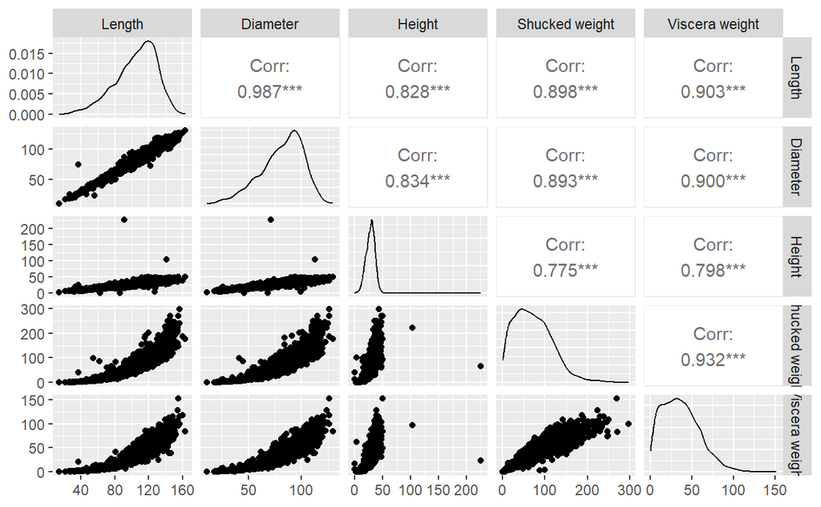

```r
ggpairs(aba[,c(2,3,4,6,7)])
```

The two variables do not have univariate or multivariate normality

Correlation between the independent variables Length, Diameter and Height

```r
cor(aba[,c(2,3,4)])
```

```
            Length  Diameter    Height
Length   1.0000000 0.9868116 0.8275536
Diameter 0.9868116 1.0000000 0.8336837
Height   0.8275536 0.8336837 1.0000000
```

This shows shows that all the three independent variables are highly correlated indicating high multicollinearity. A correlation between length and diameter of 0.986 makes it possible for us to ignore one of them in our modelling. We will test for its effect on our modelling. We will however for now use all three Length, Diameter and Height.

Correlation between the dependent variables Viscera Weight, Shucked Weight and Shell Weight

```r
cor(aba[,c(6,7,8)])
```

```
               Shucked weight Viscera weight Shell weight
Shucked weight      1.0000000      0.9319613    0.8826171
Viscera weight      0.9319613      1.0000000    0.9076563
Shell weight        0.8826171      0.9076563    1.0000000
```

Checking for correlation between all, independent and dependent variables

```r
cor(aba[,c(2,3,4,6,7,8)])
```

```
                  Length  Diameter    Height Shucked weight Viscera weight Shell weight
Length         1.0000000 0.9868116 0.8275536      0.8979137      0.9030177    0.8977056
Diameter       0.9868116 1.0000000 0.8336837      0.8931625      0.8997244    0.9053298
Height         0.8275536 0.8336837 1.0000000      0.7749723      0.7983193    0.8173380
Shucked weight 0.8979137 0.8931625 0.7749723      1.0000000      0.9319613    0.8826171
Viscera weight 0.9030177 0.8997244 0.7983193      0.9319613      1.0000000    0.9076563
Shell weight   0.8977056 0.9053298 0.8173380      0.8826171      0.9076563    1.0000000
```

This shows shows that all the three dependent variables are also highly correlated. Shell weight is of no commercial benefit and therefore can be ignored in our modelling.

**Canonical Correlation Analysis**

```r
x<-aba[,c(2,3,4)]
y<-aba[,c(6,7)]
(abcor<-matcor(x,y))
```

```
$Xcor
            Length  Diameter    Height
Length   1.0000000 0.9868116 0.8275536
Diameter 0.9868116 1.0000000 0.8336837
Height   0.8275536 0.8336837 1.0000000

$Ycor
               Shucked weight Viscera weight
Shucked weight      1.0000000      0.9319613
Viscera weight      0.9319613      1.0000000

$XYcor
                  Length  Diameter    Height Shucked weight Viscera weight
Length         1.0000000 0.9868116 0.8275536      0.8979137      0.9030177
Diameter       0.9868116 1.0000000 0.8336837      0.8931625      0.8997244
Height         0.8275536 0.8336837 1.0000000      0.7749723      0.7983193
Shucked weight 0.8979137 0.8931625 0.7749723      1.0000000      0.9319613
Viscera weight 0.9030177 0.8997244 0.7983193      0.9319613      1.0000000
```

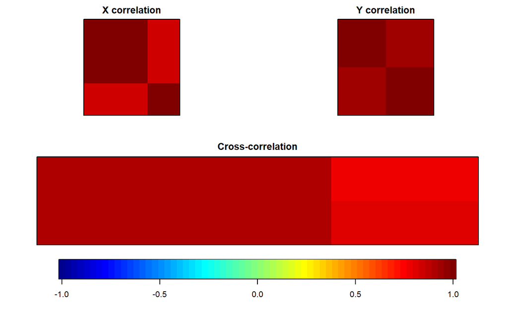

```r
img.matcor(abcor, type = 2)
```

```r
summary(ccab <- cc(x,y))
```

```
       Length Class  Mode
cor    2      -none- numeric
names  3      -none- list
xcoef  6      -none- numeric
ycoef  4      -none- numeric
scores 6      -none- list
```

```r
ccab$xcoef
```

```
                [,1]        [,2]
Length   -0.02662249  0.08488675
Diameter -0.01242911 -0.02611730
Height   -0.01629654 -0.20805034
```

```r
ccab$ycoef
```

```
                      [,1]        [,2]
Shucked weight -0.01000563  0.06132063
Viscera weight -0.02613680 -0.12306828
```

```r
ccab$cor
```

```
[1] 0.92021931 0.09118893
```

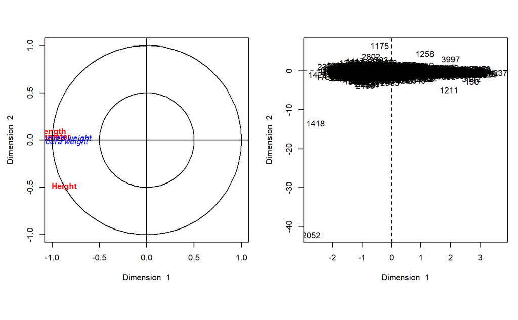

```r
plt.cc(ccab, var.label = TRUE)
```

#### **Hypothesis Testing**

```r
n <- nrow(aba)
p <- ncol(x)
q <- ncol(y)
```

```r
p.asym(ccab$cor, n, p, q, tstat = "Wilks")
```

```
Wilks' Lambda, using F-approximation (Rao's F):
              stat     approx df1  df2      p.value
1 to 2:  0.1519225 2177.22737   6 8344 0.000000e+00
2 to 2:  0.9916846   17.49561   2 4173 2.712891e-08
```

```r
p.asym(ccab$cor, n, p, q, tstat = "Pillai")
```

```
 Pillai-Bartlett Trace, using F-approximation:
                stat     approx df1  df2      p.value
1 to 2:  0.855118995 1038.94686   6 8346 0.000000e+00
2 to 2:  0.008315421   17.43091   2 8350 2.790031e-08
```

```r
p.asym(ccab$cor, n, p, q, tstat = "Hotelling")
```

```
 Hotelling-Lawley Trace, using F-approximation:
                stat     approx df1  df2      p.value
1 to 2:  5.535952568 3848.40969   6 8342 0.000000e+00
2 to 2:  0.008385147   17.49561   2 8346 2.615995e-08
```

The three hypothesis tests broadly agree and as the p value for both canonical correlations is less than 0.05 we can consider that both canonical correlations are statically significant.

**Permutation Testing**

```r
p.perm(x,y, type = "Wilks")
```

```
 Permutation resampling using Wilks 's statistic:
     stat0     mstat nboot nexcess p
 0.1519225 0.9985328   999       0 0
```

```r
p.perm(x,y, type = "Hotelling")
```

```
 Permutation resampling using Hotelling 's statistic:
    stat0      mstat nboot nexcess p
 5.535953 0.00144397   999       0 0
```

```r
p.perm(x,y, type = "Pillai")
```

```
 Permutation resampling using Pillai 's statistic:
    stat0       mstat nboot nexcess p
 0.855119 0.001424118   999       0 0
```

The p value of 0 further confirms that the first canonical correlations are statistically significant.

**Multivariate Linear Modeling and Analysis**

We would build a linear model to predict shucked weight and visceral weight by regressing over independent variables of Length, Diameter and Height.

```r
amlm <- lm(cbind(`Shucked weight`,`Viscera weight`)~Length+Diameter+Height, data=aba)
summary(amlm)
```

```
Response Shucked weight :

Call:
lm(formula = `Shucked weight` ~ Length + Diameter + Height, data = aba)

Residuals:
    Min      1Q  Median      3Q     Max
-79.131 -12.860  -3.545   8.390 139.324

Coefficients:
             Estimate Std. Error t value Pr(>|t|)
(Intercept) -99.10796    1.38894 -71.355  < 2e-16 ***
Length        1.13521    0.07703  14.737  < 2e-16 ***
Diameter      0.47470    0.09476   5.009 5.69e-07 ***
Height        0.47624    0.06483   7.346 2.45e-13 ***
---
Signif. codes:  0 ‘***’ 0.001 ‘**’ 0.01 ‘*’ 0.05 ‘.’ 0.1 ‘ ’ 1

Residual standard error: 19.33 on 4173 degrees of freedom
Multiple R-squared:  0.8106,    Adjusted R-squared:  0.8105
F-statistic:  5954 on 3 and 4173 DF,  p-value: < 2.2e-16


Response Viscera weight :

Call:
lm(formula = `Viscera weight` ~ Length + Diameter + Height, data = aba)

Residuals:
    Min      1Q  Median      3Q     Max
-80.821  -6.007  -1.674   4.334  70.626

Coefficients:
             Estimate Std. Error t value Pr(>|t|)
(Intercept) -48.36393    0.65924 -73.363  < 2e-16 ***
Length        0.50274    0.03656  13.750  < 2e-16 ***
Diameter      0.25588    0.04498   5.689 1.37e-08 ***
Height        0.39145    0.03077  12.721  < 2e-16 ***
---
Signif. codes:  0 ‘***’ 0.001 ‘**’ 0.01 ‘*’ 0.05 ‘.’ 0.1 ‘ ’ 1

Residual standard error: 9.173 on 4173 degrees of freedom
Multiple R-squared:  0.8251,    Adjusted R-squared:  0.8249
F-statistic:  6560 on 3 and 4173 DF,  p-value: < 2.2e-16
```

```r
coef(amlm)
```

```
            Shucked weight Viscera weight
(Intercept)    -99.1079562    -48.3639333
Length           1.1352133      0.5027393
Diameter         0.4746994      0.2558781
Height           0.4762412      0.3914518
```

```r
confint(amlm, level = 0.95)
```

```
                                  2.5 %      97.5 %
Shucked weight:(Intercept) -101.8310090 -96.3849035
Shucked weight:Length         0.9841868   1.2862398
Shucked weight:Diameter       0.2889118   0.6604871
Shucked weight:Height         0.3491375   0.6033449
Viscera weight:(Intercept)  -49.6563967 -47.0714699
Viscera weight:Length         0.4310565   0.5744222
Viscera weight:Diameter       0.1676963   0.3440599
Viscera weight:Height         0.3311236   0.4517800
```

```r
vcov(amlm)
```

```
                           Shucked weight:(Intercept) Shucked weight:Length Shucked weight:Diameter
Shucked weight:(Intercept)                1.929140897         -4.401657e-02            0.0322145187
Shucked weight:Length                    -0.044016568          5.934146e-03           -0.0069908668
Shucked weight:Diameter                   0.032214519         -6.990867e-03            0.0089801910
Shucked weight:Height                     0.005203730         -2.717890e-04           -0.0011523033
Viscera weight:(Intercept)                0.577104448         -1.316760e-02            0.0096370058
Viscera weight:Length                    -0.013167601          1.775206e-03           -0.0020913249
Viscera weight:Diameter                   0.009637006         -2.091325e-03            0.0026864332
Viscera weight:Height                     0.001556701         -8.130595e-05           -0.0003447127
                           Shucked weight:Height Viscera weight:(Intercept) Viscera weight:Length
Shucked weight:(Intercept)          5.203730e-03                0.577104448         -1.316760e-02
Shucked weight:Length              -2.717890e-04               -0.013167601          1.775206e-03
Shucked weight:Diameter            -1.152303e-03                0.009637006         -2.091325e-03
Shucked weight:Height               4.203087e-03                0.001556701         -8.130595e-05
Viscera weight:(Intercept)          1.556701e-03                0.434598659         -9.916093e-03
Viscera weight:Length              -8.130595e-05               -0.009916093          1.336850e-03
Viscera weight:Diameter            -3.447127e-04                0.007257317         -1.574909e-03
Viscera weight:Height               1.257358e-03                0.001172301         -6.122888e-05
                           Viscera weight:Diameter Viscera weight:Height
Shucked weight:(Intercept)            0.0096370058          1.556701e-03
Shucked weight:Length                -0.0020913249         -8.130595e-05
Shucked weight:Diameter               0.0026864332         -3.447127e-04
Shucked weight:Height                -0.0003447127          1.257358e-03
Viscera weight:(Intercept)            0.0072573168          1.172301e-03
Viscera weight:Length                -0.0015749090         -6.122888e-05
Viscera weight:Diameter               0.0020230658         -2.595920e-04
Viscera weight:Height                -0.0002595920          9.468753e-04
```

```r
head(resid(amlm))
```

```
  Shucked weight Viscera weight
1      -2.998097      -3.302033
2       5.811612       2.264507
3     -22.657921      -8.689397
4      -4.249905      -1.542526
5      10.254347       3.770124
6      -6.715725      -1.659182
```

**Hypothesis Testing by ANOVA**

```r
anova(amlm, test="Wilks")
```

```
Analysis of Variance Table

              Df   Wilks approx F num Df den Df    Pr(>F)
(Intercept)    1 0.05246    37677      2   4172 < 2.2e-16 ***
Length         1 0.15432    11431      2   4172 < 2.2e-16 ***
Diameter       1 0.98339       35      2   4172 6.722e-16 ***
Height         1 0.96250       81      2   4172 < 2.2e-16 ***
Residuals   4173
---
Signif. codes:  0 ‘***’ 0.001 ‘**’ 0.01 ‘*’ 0.05 ‘.’ 0.1 ‘ ’ 1
```

As we have seen above the correlation between Length and Diameter is 0.98 making them highly correlated. We therefore test if diameter has an extra predictive effect on the shucked and viscera weights.

```r
ramlm<- lm(cbind(`Shucked weight`,`Viscera weight`)~Length+Height, data=aba)
anova(amlm,ramlm)
```

```
Analysis of Variance Table

Model 1: cbind(`Shucked weight`, `Viscera weight`) ~ Length + Diameter +
    Height
Model 2: cbind(`Shucked weight`, `Viscera weight`) ~ Length + Height
  Res.Df Df Gen.var.    Pillai approx F num Df den Df    Pr(>F)
1   4173      137.63
2   4174  1   138.18 0.0084887   17.859      2   4172 1.892e-08 ***
---
Signif. codes:  0 ‘***’ 0.001 ‘**’ 0.01 ‘*’ 0.05 ‘.’ 0.1 ‘ ’ 1
```

This test gives a p value less than 0.05 and therefore conclude that Diameter has an effect on the prediction of shucked and viscera weight

```r
predict(amlm, newdata = testing[1:5,] ,interval ='confidence')
```

```
  Shucked weight Viscera weight
1       42.59520      21.105876
2      101.81039      50.955214
3       17.59710       9.217623
4      -33.08457     -15.769307
5       52.36392      26.473788
```

**Pearson Residuals**

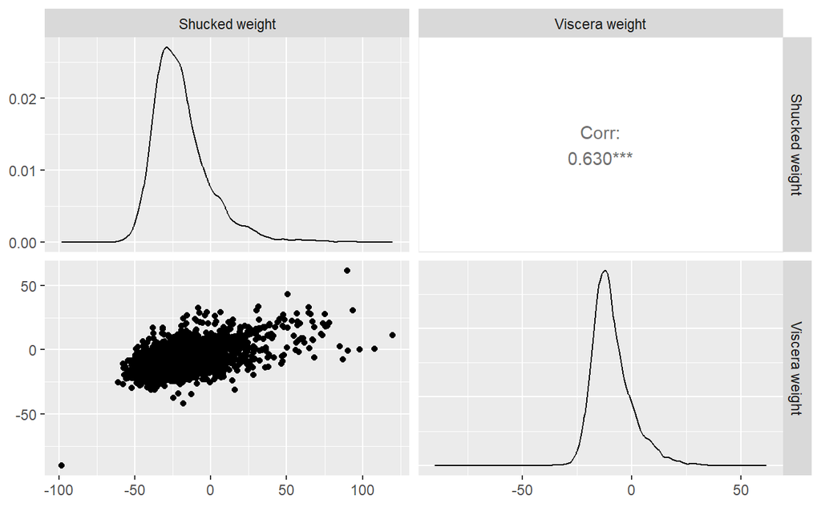

```r
sds <- amlm %>% estVar %>% diag %>% sqrt
PR <- sweep(resid(amlm), 2, sds,)
ggpairs(as_tibble(PR))
```

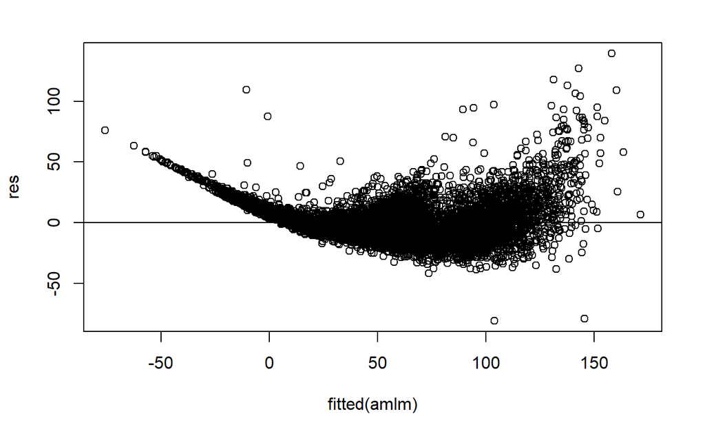

```r
res<- resid(amlm)
plot(fitted(amlm), res)
abline(0,0)
```

Please access the original RMD file from

https://drive.google.com/file/d/1jneyhTl8bTup8qs_N19h3H0BOcQbzBzd/view?usp=share_link